# Price Optimisation: Can we find an optimial price for every product of a Cafe, that would maximise profits?

## Daily quantity sold model, for the other products, only based on price

```python
burger_coke = product_datasets["BURGER_COKE"][["QUANTITY","PRICE"]]
burger_lemonade = product_datasets["BURGER_LEMONADE"][["QUANTITY","PRICE"]]
burger_coke_coffee = product_datasets["BURGER_COKE_COFFEE"][["QUANTITY","PRICE"]]


other_products = [burger_coke, burger_lemonade, burger_coke_coffee]

burger_coke_coffee
```

|  | QUANTITY | PRICE |
| --- | --- | --- |
| 3 | 30 | 12.60 |
| 7 | 34 | 12.60 |
| 11 | 28 | 12.60 |
| 15 | 42 | 12.60 |
| 19 | 58 | 12.60 |
| ... | ... | ... |
| 5371 | 54 | 11.26 |
| 5375 | 50 | 11.26 |
| 5379 | 50 | 11.26 |
| 5383 | 54 | 11.26 |
| 5387 | 50 | 11.26 |

1347 rows × 2 columns

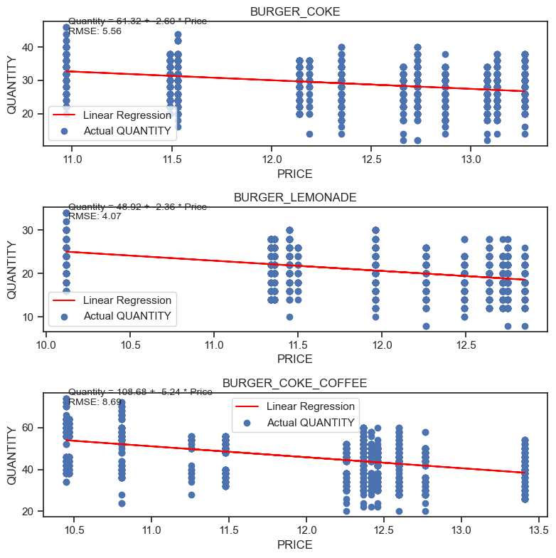

```python
# Perform linear regression and store the equations
other_linear_equations = []

other_dataset_names = ["BURGER_COKE", "BURGER_LEMONADE", "BURGER_COKE_COFFEE"]

fig, axes = plt.subplots(3, 1, figsize=(8, 8))

for i, (dataset_name, dataset) in enumerate(zip(other_dataset_names, other_products)):
    X = sm.add_constant(dataset['PRICE'].astype(float))  # Add a constant term to the independent variable
    y = dataset["QUANTITY"].astype(int)

    model = sm.OLS(y, X)  # Create an ordinary least squares (OLS) model
    results = model.fit()  # Fit the model to the data

    # Store the linear equation
    constant = results.params['const']
    coefficient = results.params['PRICE']
    equation = f"Quantity = {constant:.2f} + {coefficient:.2f} * Price"
    other_linear_equations.append(equation)

    coefficients[dataset_name] = [constant,coefficient]

    # Calculate RMSE
    y_pred = results.predict(X)
    rmse = np.sqrt(np.mean((y - y_pred) ** 2))

    # Plot actual QUANTITY values against PRICE values
    ax = axes[i]
    ax.scatter(dataset["PRICE"], y, label='Actual QUANTITY')
    ax.plot(dataset["PRICE"], results.fittedvalues, color='red', label='Linear Regression')  # Plot the linear regression line
    ax.set_xlabel("PRICE")
    ax.set_ylabel("QUANTITY")
    ax.set_title(dataset_name)
    ax.legend()

    # Add linear equation formula and RMSE to the plot
    text = f"{equation}\nRMSE: {rmse:.2f}"
    ax.text(0.05, 0.9, text, transform=ax.transAxes, fontsize=10)

plt.tight_layout()
plt.show();
```

```python
# Print the linear equations
for dataset_name, equation in zip(other_dataset_names, other_linear_equations):
    print(f"{dataset_name}: {equation}")

# Print the linear equations
for dataset_name, equation in zip(dataset_names, linear_equations):
    print(f"{dataset_name}: {equation}")
```

```
BURGER_COKE: Quantity = 61.32 + -2.60 * Price
BURGER_LEMONADE: Quantity = 48.92 + -2.36 * Price
BURGER_COKE_COFFEE: Quantity = 108.68 + -5.24 * Price
Colder Weekday Burger: Quantity = 219.85 + -8.48 * Price
Colder Weekend Burger: Quantity = 133.61 + -4.61 * Price
Warmer Weekday Burger: Quantity = 201.14 + -7.52 * Price
Warmer Weekend Burger: Quantity = 142.45 + -5.36 * Price
```

*We have, per product, the price elasticity estimation. Let's use them, along with a formula to calculate the optimal price for each product, to find product prices maximising company revenue. But before that, let's make sure optimising for one product is not negatively associated with another. If so, we will have to apply tradoffs, in favor of our star products surely*

## Investigating eventual negative association between a product sales and another ones, and therefore optimisation tradoffs to apply. Quantity correlation matrix

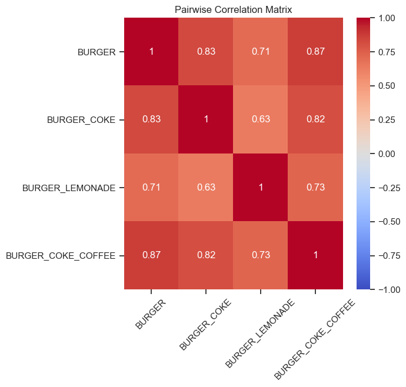

```python
product_names = list(product_datasets.keys())

correlation_matrix = pd.DataFrame(index=product_datasets.keys(), columns=product_datasets.keys())

for product1 in product_datasets.keys():
    for product2 in product_datasets.keys():
        quantity1 = product_datasets[product1]['QUANTITY'].reset_index(drop = True)
        quantity2 = product_datasets[product2]['QUANTITY'].reset_index(drop = True)
        correlation = quantity1.corr(quantity2)
        correlation_matrix.loc[product1, product2] = correlation

"""# Display the correlation matrix
print("Pairwise Correlation Matrix:")
print(correlation_matrix)"""

# Generate correlation matrix
correlation_matrix = correlation_matrix.astype(float)  # Convert the values to float

# Plot correlation matrix as a heatmap
plt.figure(figsize=(6, 6))
sns.heatmap(correlation_matrix, annot=True, cmap="coolwarm", vmin=-1, vmax=1)
plt.title("Pairwise Correlation Matrix")
plt.xticks(rotation=45)
plt.yticks(rotation=0)
plt.show();
```

*Increasing the quantity sold for a product will not, based on historical data, lead to decreasing the quantity sold for another. That would have been an issue if we wanted to optimise for Burger Coke or Burger Lemonade, our two lowest revenue generating product, and if that had a negative impact of the sales of our two star products, Burger and BCC*

*We can safely use our above linear equations for every product, and find the price that maximises both quantity and revenue*